# Was macht ein Teilchenphysiker?

Lattice QCD – Quarks auf dem Gitter

Gianluca · Doktorand · Theoretische Teilchenphysik

2026-04-13

## Warum Teilchenphysik?

- Woraus besteht die Welt wirklich?
- Warum haben Teilchen Masse?
- Was hält Protonen & Neutronen zusammen?

## Das Standardmodell (Überblick)

Alle bekannten Elementarteilchen

| Fermionen (Materie) |  |  | Bosonen (Kräfte) |  |
| --- | --- | --- | --- | --- |
| **up (u)** | **charm (c)** | **Elektron (e)** **Elektronneutrino (νₑ)** | **Photon (γ)** | **Higgs (H)** |
| **down (d)** | **top (t)** | **Muon (μ)** **Muonneutrino (ν<sub>μ</sub>)** | **W±** | **Z** |
| **strange (s)** | **bottom (b)** | **Tau (τ)** **Tauneutrino (ν<sub>τ</sub>)** | **Gluon (g)** |  |

■ Quarks ■ Leptonen ■ Kraftbosonen ■ Higgs

## Die starke Wechselwirkung

- Beschrieben durch: **QCD** (Quantenchromodynamik)
- Quarks tragen *Farbladung*
- Vermittelt durch Gluonen

## Das Problem

QCD-Gleichungen sind bekannt …

### … aber extrem schwer zu lösen!

Warum?

## Klassische Physik vs. Quantenphysik

- **Klassische Physik:** Natur wählt den Pfad mit minimaler *Wirkung*

Die *Wirkung* ist eine Zahl, die angibt, wie sehr sich das Universum “anstrengen muss” um einen Pfad durchzuführen

## Klassische Physik vs. Quantenphysik

- **Klassische Physik:** Natur wählt den Pfad mit minimaler Wirkung
- **Quantenphysik:** Alle Pfade tragen bei, aber kleine Wirkung → größere Bedeutung

Aufsummierung und Mittelung aller Pfade wird als *Pfadintegral* bezeichnet

## Pfadintegral in der QED

Beispiel: Elektron–Elektron-Streuung

Ein Diagramm = ein Term im Pfadintegral

## Pfadintegral in der QED

Beispiel: Elektron–Elektron-Streuung

[figure not shown]

**Speziell in der QED**: Je mehr Wechselwirkungen, desto unwichtiger werden Pfade (ist nicht immer so)

## Pfadintegral in der QED

Beispiel: Elektron–Elektron-Streuung

[figure not shown]

→ Um Sachen auszurechnen und mit Experimenten vergleichen zu können braucht man nur eine **endliche** Anzahl an Diagrammen

## Wichtige Klarstellung

- Feynman-Diagramme sind **keine echten Teilchenbahnen**
- Sie sind ein mathematischer Trick
- Hilfreich, um das Pfadintegral übersichtlich zu berechnen
- Ansonsten müsste man mit sogenannten *Quantenfeldern* rechnen (schwer!)

## Und jetzt: QCD

- Starke Kopplung: Komplizierte Diagramme werden **nicht** unwichtig
- Unendlich viele wichtige Diagramme

**→ Jetzt müssen wir mit Feldern rechnen!**

## Die Idee von Lattice QCD

- Beschränke das Universum auf ein **sehr kleines Volumen** (kleiner als ein Atom)
- Raum und Zeit werden zum *Gitter* (eng.: *Lattice*)
- Quarks sitzen auf Gitterpunkten
- Gluonen auf den Verbindungen
- An jedem Punkt und an jeder Verbindung haben die Felder irgendeinen Wert
- Genaue Größe des Gitters wird vor der Simulation festgelegt
- Echte Physik bekommt man nur im Fall *a → 0*

[figure not shown]

## Lattice QCD

**Wie rechnet man jetzt auf dem Gitter?**

- Ähnlich zum Pfadintegral brauchen wir jetzt die wichtigen **Feldkonfigurationen**
- Aber wie gesagt, gibt es in der QCD unendlich viele

**Brauchen wir denn wirklich alle?**

## Lattice QCD

- Vergleich mit etwas bekanntem: **Umfragen**
- In Umfragen wird nur ein kleiner *representativer Teil* der Bevölkerung befragt
- Das Ergebnis hat dann eine gewisse Unsicherheit, aber das ist okay
- Genau so simulieren wir also auch nur einen representativen Teil der wichtigen Feldkonfigurationen in Lattice QCD

## Lattice QCD

- **Weitere Problem:** Wissen wir welche Konfigurationen wichtig sind? Und wie generieren wir sie?
- Antwort auf die erste Frage: Ja, aber nur wenn wir sie schon haben…
- Antwort auf die zweite Frage: Es ist schwer…

## Lattice QCD

**Die (soweit beste) Lösung:**

1. Wir starten mit irgendeiner Konfig
2. Ändern sie an jedem Punkt und jeder Verbindung ein bisschen
3. Checken ob die neue Konfig “wichtig genug” ist und falls ja, ist diese jetzt unser neuer Start
4. So oft wiederholen bis die Unsicherheit auf Messwerten klein genug ist

Wird auch *Markov Chain Monte Carlo Simulation (MCMC)* genannt

## MCMC

- Funktioniert ganz gut, da über die Jahre sehr viele Tricks und Verbesserungen vorgeschlagen wurden
- **ABER**, da jede Konfig direkt von der letzten abhängt, gibt es neue Schwierigkeiten
- Die größte Schwierigkeit ist, dass Simulationen in bestimmten Bereichen **stecken bleiben**

## MCMC

- Die größte Schwierigkeit ist, dass Simulationen in bestimmten Bereichen **stecken bleiben**

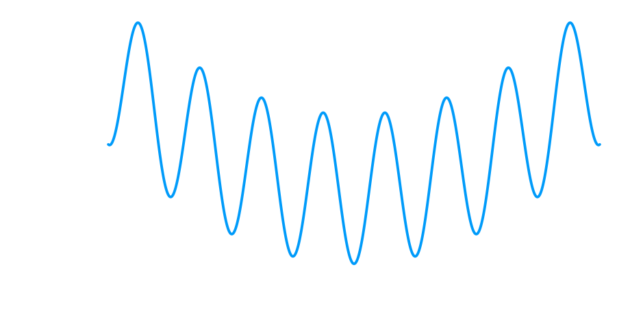

## Supercomputer statt Kreide

- Simulationen mit Millionen Variablen
- Wochenlange Rechnungen
- Oft auf Supercomputern

## Was berechnen wir damit?

- Massen von Protonen & Neutronen
- Warum Protonen stabil sind
- Vergleich mit Experimenten (CERN, etc.)

## Was mache ich konkret?

- Entwicklung & Analyse von Simulationen
- Viel C++ / Python / Mathematik
- Diskussion mit Physiker:innen weltweit

## Alltag eines PhD-Studierenden

- Forschen & Programmieren
- Papers lesen & schreiben
- Konferenzen & Lehre

## Warum Physik studieren?

- Lernen, komplexe Probleme zu lösen
- Sehr breite Berufsmöglichkeiten
- Neugier als Job 😄

## Take-Home Message

- Die Welt ist auf kleinster Skala extrem spannend
- Lattice QCD verbindet Physik & Informatik
- Vielleicht sitzt hier die nächste Physikerin / der nächste Physiker 😉